# Анализ данных о медицинских расходах

Вейбер Е.Н. 23.М08-мм

07-03-2024

## Введение

В этом отчете проведен анализ данных о медицинских расходах с целью выявления особенностей распределения ключевых переменных, а также оценки влияния пола на эти расходы и изучения взаимосвязей между различными переменными.

## Загрузка данных

Данные о медицинских расходах были загружены и проверены с помощью следующего кода:

```r
# Загрузка необходимых библиотек
library(tidyverse)
library(ggplot2)
library(readr)
library(corrplot)

# Шаг 1: Загрузка данных и создание гистограмм
data <- read_csv("~/Downloads/mexpenditures.csv")
head(data)
```

```
## # A tibble: 6 × 7
##     age sex      bmi children smoker region    charges
##   <dbl> <chr>  <dbl>    <dbl> <chr>  <chr>       <dbl>
## 1    19 female  27.9        0 yes    southwest  16885.
## 2    18 male    33.8        1 no     southeast   1726.
## 3    28 male    33          3 no     southeast   4449.
## 4    33 male    22.7        0 no     northwest  21984.
## 5    32 male    28.9        0 no     northwest   3867.
## 6    31 female  25.7        0 no     southeast   3757.
```

## Гистограммы частот

Гистограммы частот были созданы с помощью следующего кода:

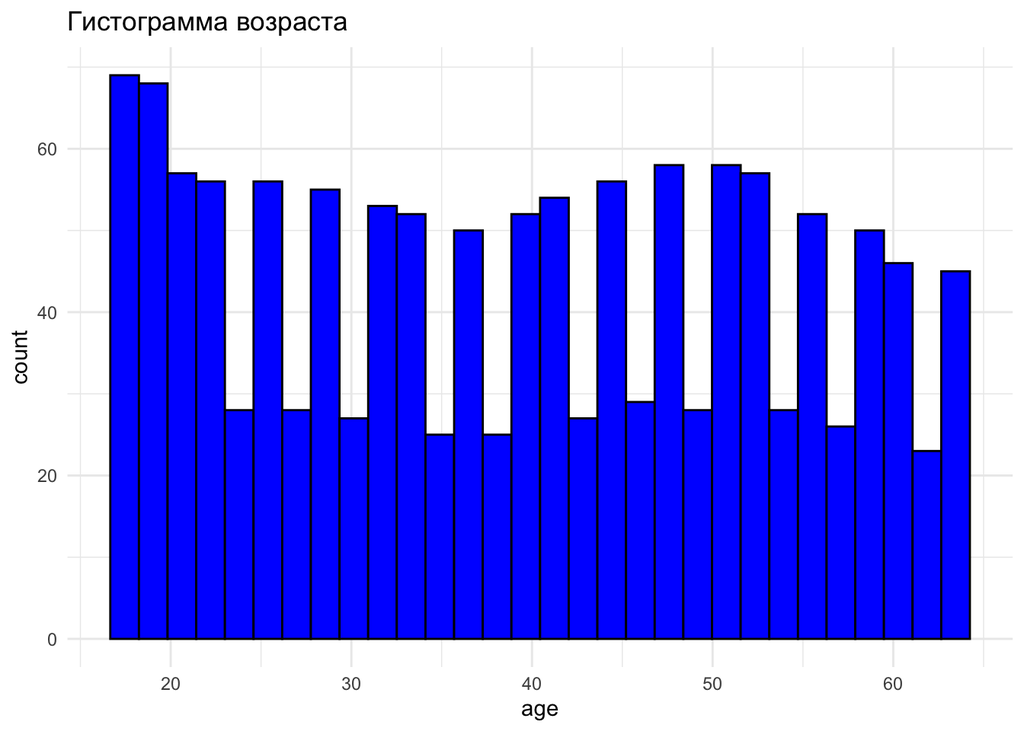

```r
# Создание гистограмм для возраста, BMI и расходов
ggplot(data, aes(x=age)) +
  geom_histogram(bins=30, fill='blue', color='black') +
  ggtitle("Гистограмма возраста") +
  theme_minimal()
```

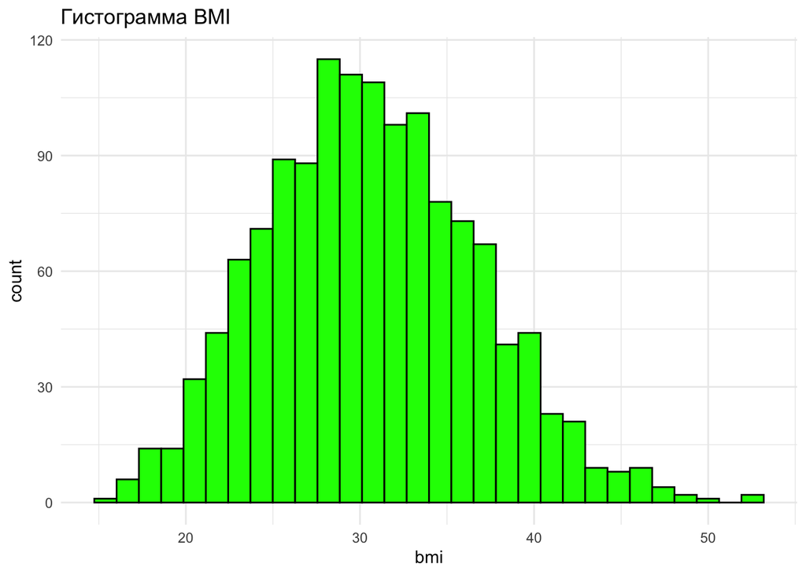

```r
ggplot(data, aes(x=bmi)) +
  geom_histogram(bins=30, fill='green', color='black') +
  ggtitle("Гистограмма BMI") +
  theme_minimal()
```

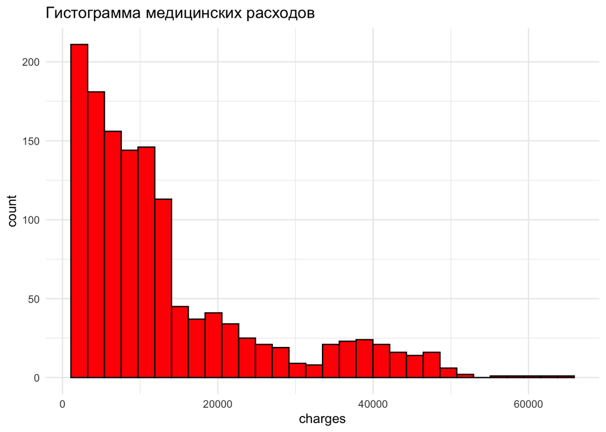

```r
ggplot(data, aes(x=charges)) +
  geom_histogram(bins=30, fill='red', color='black') +
  ggtitle("Гистограмма медицинских расходов") +
  theme_minimal()
```

## Выбросы

Для анализа выбросов был использован boxplot:

```r
# Подробнее про выбросы

# Функция boxplot возвращает список, одним из элементов которого является $out, содержащий выбросы
get_boxplot_outliers <- function(variable) {
  bp <- boxplot(variable, plot = FALSE)  # plot=FALSE чтобы не создавать график
  return(bp$out)
}

# Получаем выбросы для 'age', 'bmi', 'charges'
outliers_age <- get_boxplot_outliers(data$age)
outliers_bmi <- get_boxplot_outliers(data$bmi)
outliers_charges <- get_boxplot_outliers(data$charges)

# Выводим количество выбросов
length(outliers_age)
```

```
## [1] 0
```

```r
length(outliers_bmi)
```

```
## [1] 9
```

```r
length(outliers_charges)
```

```
## [1] 139
```

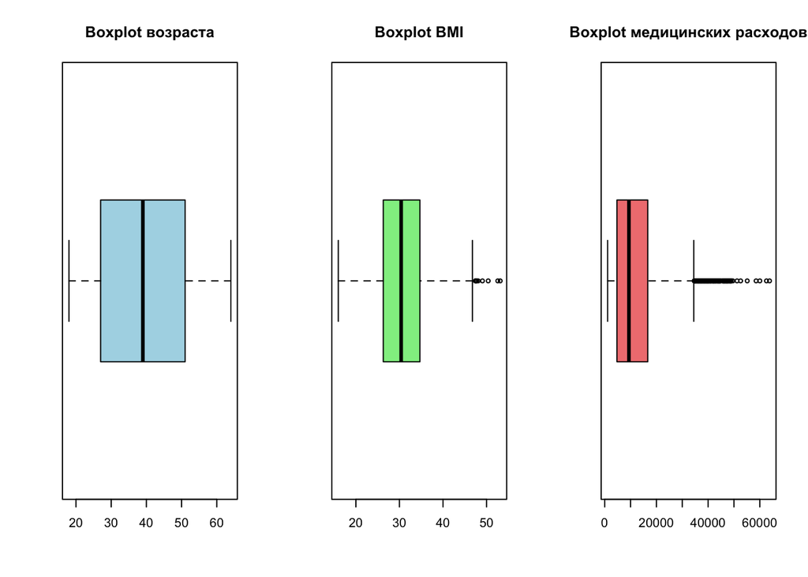

```r
# Визуализация выбросов с помощью boxplot для каждой переменной
par(mfrow=c(1,3))  # Определяем макет для 3 графиков в одной строке

# Возраст
boxplot(data$age, main="Boxplot возраста", horizontal = TRUE, col = "lightblue")

# BMI
boxplot(data$bmi, main="Boxplot BMI", horizontal = TRUE, col = "lightgreen")

# Медицинские расходы
boxplot(data$charges, main="Boxplot медицинских расходов", horizontal = TRUE, col = "lightcoral")
```

```r
# Восстановление стандартного макета графиков
par(mfrow=c(1,1))
```

## Сравнение выраженности непрерывных признаков между группами мужчин и женщин

Выбор статистического теста зависел от нормальности распределения и был реализован функцией perform_statistical_test:

```r
# Функция для выполнения статистического теста в зависимости от нормальности распределения
perform_statistical_test <- function(data, variable) {
  # Проверка на нормальность для мужчин и женщин
  shapiro_test_women <- shapiro.test(data[data$sex == 'female', ][[variable]])
  shapiro_test_men <- shapiro.test(data[data$sex == 'male', ][[variable]])

  # Выбор и выполнение теста
  if (shapiro_test_women$p.value > 0.05 && shapiro_test_men$p.value > 0.05) {
    # Если распределения нормальные, применяем t-тест
    test_result <- t.test(data[[variable]] ~ data$sex)
  } else {
    # Иначе применяем непараметрический тест Манна-Уитни
    test_result <- wilcox.test(data[[variable]] ~ data$sex)
  }

  # Возвращаем результат
  return(test_result)
}

# Применяем функцию к переменным 'age', 'bmi', 'charges'
test_result_age <- perform_statistical_test(data, 'age')
test_result_bmi <- perform_statistical_test(data, 'bmi')
test_result_charges <- perform_statistical_test(data, 'charges')

# Выводим результаты тестов
print("Результаты теста для возраста:")
```

```
## [1] "Результаты теста для возраста:"
```

```r
print(test_result_age)
```

```
##
##  Wilcoxon rank sum test with continuity correction
##
## data:  data[[variable]] by data$sex
## W = 229131, p-value = 0.4468
## alternative hypothesis: true location shift is not equal to 0
```

```r
print("Результаты теста для BMI:")
```

```
## [1] "Результаты теста для BMI:"
```

```r
print(test_result_bmi)
```

```
##
##  Wilcoxon rank sum test with continuity correction
##
## data:  data[[variable]] by data$sex
## W = 212180, p-value = 0.1014
## alternative hypothesis: true location shift is not equal to 0
```

```r
print("Результаты теста для медицинских расходов:")
```

```
## [1] "Результаты теста для медицинских расходов:"
```

```r
print(test_result_charges)
```

```
##
##  Wilcoxon rank sum test with continuity correction
##
## data:  data[[variable]] by data$sex
## W = 221304, p-value = 0.7287
## alternative hypothesis: true location shift is not equal to 0
```

## Корреляционный анализ

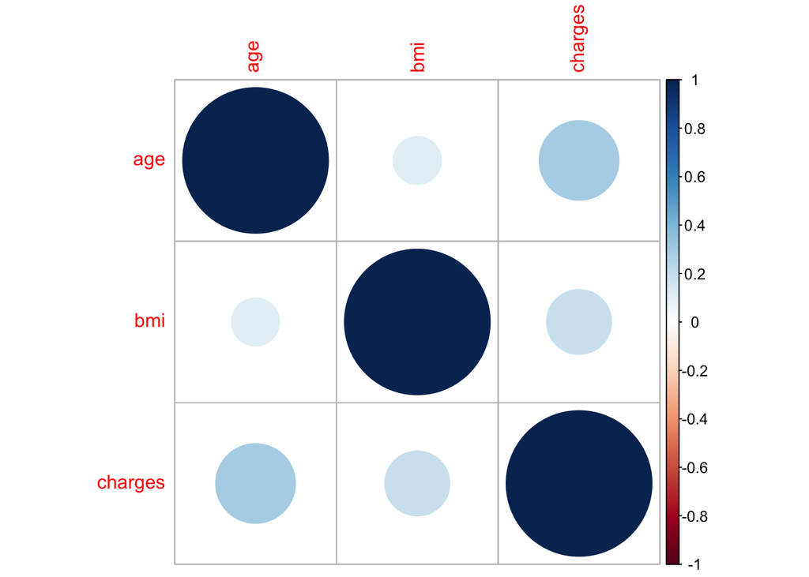

```r
# Шаг 3: Корреляционный анализ
cor_matrix <- cor(data[,c('age', 'bmi', 'charges')])

# Визуализация корреляционной матрицы
corrplot::corrplot(cor_matrix, method = "circle")
```

```r
print(cor_matrix)
```

```
##               age       bmi   charges
## age     1.0000000 0.1092719 0.2990082
## bmi     0.1092719 1.0000000 0.1983410
## charges 0.2990082 0.1983410 1.0000000
```

## Статистический вывод о коэффициентах корреляции

```r
# Статистический вывод между age и bmi
cor_test_age_bmi <- cor.test(data$age, data$bmi)
print("Корреляция между возрастом и BMI:")
```

```
## [1] "Корреляция между возрастом и BMI:"
```

```r
print(cor_test_age_bmi)
```

```
##
##  Pearson's product-moment correlation
##
## data:  data$age and data$bmi
## t = 4.0181, df = 1336, p-value = 6.194e-05
## alternative hypothesis: true correlation is not equal to 0
## 95 percent confidence interval:
##  0.05600895 0.16191463
## sample estimates:
##       cor
## 0.1092719
```

```r
# Статистический вывод между age и charges
cor_test_age_charges <- cor.test(data$age, data$charges)
print("Корреляция между возрастом и медицинскими расходами:")
```

```
## [1] "Корреляция между возрастом и медицинскими расходами:"
```

```r
print(cor_test_age_charges)
```

```
##
##  Pearson's product-moment correlation
##
## data:  data$age and data$charges
## t = 11.453, df = 1336, p-value < 2.2e-16
## alternative hypothesis: true correlation is not equal to 0
## 95 percent confidence interval:
##  0.2494139 0.3470381
## sample estimates:
##       cor
## 0.2990082
```

```r
# Статистический вывод между bmi и charges
cor_test_bmi_charges <- cor.test(data$bmi, data$charges)
print("Корреляция между BMI и медицинскими расходами:")
```

```
## [1] "Корреляция между BMI и медицинскими расходами:"
```

```r
print(cor_test_bmi_charges)
```

```
##
##  Pearson's product-moment correlation
##
## data:  data$bmi and data$charges
## t = 7.3966, df = 1336, p-value = 2.459e-13
## alternative hypothesis: true correlation is not equal to 0
## 95 percent confidence interval:
##  0.1463052 0.2492822
## sample estimates:
##      cor
## 0.198341
```

## Интерпретация результатов

### Анализ гистограмм непрерывных признаков

На гистограмме возраста (age) видно равномерное распределение. Не наблюдается значительных выбросов.

Гистограмма индекса массы тела (bmi) имеет приближённо нормальное распределение. Выбросы присутствуют в правой части распределения, так как есть значения далеко превышающие среднее.

Гистограмма медицинских расходов (charges) имеет скошенное вправо распределение, с длинным “хвостом” высоких значений, что указывает на наличие выбросов. Большая часть расходов сосредоточена в левой части графика, но есть значительное количество очень высоких значений.

### Анализ выбросов

На основе межквартильного размаха (IQR) было определено, что:

1. Для признака age выбросов не обнаружено.
2. Для признака bmi обнаружено 9 выбросов.
3. Для признака charges обнаружено 139 выбросов.

Выбросы в bmi и charges, возможно, указывают на особенности в данных, которые могут быть связаны с редкими заболеваниями или высокой стоимостью медицинских услуг.

### Анализ выраженности непрерывных признаков между группами мужчин и женщин

- **Результаты теста для возраста:** *P-значение = 0.4468* показывает отсутствие статистически значимых различий в возрасте между мужчинами и женщинами в данном наборе данных.
- **Результаты теста для BMI:** *P-значение = 0.1014.* Также, как и с возрастом, нет достаточных доказательств статистически значимых различий в индексе массы тела между мужчинами и женщинами.
- **Результаты теста для медицинских расходов:** *P-значение = 0.7287* указывает на отсутствие статистически значимых различий в медицинских расходах между мужчинами и женщинами. Очень высокое p-значение может говорить о том, что любые наблюдаемые различия в медицинских расходах между полами скорее всего случайны.
- **Общий вывод:** В целом, результаты тестов показывают, что в данном наборе данных не наблюдается статистически значимых различий по возрасту, индексу массы тела (BMI) и медицинским расходам между мужчинами и женщинами. Вероятно, для этих переменных пол не является дифференцирующим фактором, влияющим на их значения в представленном наборе данных.

### Анализ корреляции непрерывных признаков

Матрица корреляции показывает следующие коэффициенты корреляции Пирсона между непрерывными переменными:

- *Возраст (age)* и *медицинские расходы (charges)* : 0.30, что указывает на небольшую положительную корреляцию.
- *Индекс массы тела (bmi)* и *медицинские расходы (charges)* : 0.20, что также указывает на небольшую положительную корреляцию.
- *Возраст (age)* и *индекс массы тела (bmi)*: 0.11, что говорит о очень слабой положительной корреляции.  
  Интерпретируя эти результаты, можно сказать, что медицинские расходы имеют тенденцию увеличиваться с возрастом и с повышением BMI, но эти взаимосвязи не очень сильные.

### Анализ статистического вывода о коэффициентах корреляции

*Результаты теста корреляции Пирсона между возрастом и индексом массы тела (BMI):*

- *Коэффициент корреляции (cor)*: Значение коэффициента корреляции примерно равно 0.109, что указывает на наличие слабой положительной линейной связи между возрастом и BMI. Слабая корреляция говорит о том, что с увеличением возраста BMI имеет тенденцию к небольшому увеличению, но эта взаимосвязь не является сильной.
- *P-значение (p-value)*: p-значение примерно равно 6.194e-05, что значительно меньше стандартного порога в 0.05. Это означает, что наблюдаемая корреляция между возрастом и BMI статистически значима, и вероятность получить такое или более экстремальное значение коэффициента корреляции при условии, что на самом деле между переменными нет связи (нулевая гипотеза верна), крайне мала.
- *95% доверительный интервал*: Доверительный интервал для коэффициента корреляции находится между 0.056 и 0.162. Этот интервал указывает на диапазон, в котором с 95% вероятностью может находиться истинный коэффициент корреляции между возрастом и BMI в генеральной совокупности. Тот факт, что весь интервал находится выше нуля, подтверждает положительную связь между переменными.
- **Общая интерпретация**:  
  Результаты теста указывают на наличие статистически значимой, хотя и слабой, положительной корреляции между возрастом и индексом массы тела (BMI) в рассматриваемом наборе данных. Можно сделать вывод, что с возрастом люди склонны иметь немного более высокий BMI, но влияние возраста на BMI не является сильным, и другие факторы могут играть более значительную роль в определении индекса массы тела человека.

*Результаты теста корреляции Пирсона между возрастом и медицинскими расходами:*

- *Коэффициент корреляции (cor)*: Значение составляет примерно 0.299. Это указывает на наличие от слабой до умеренной положительной линейной связи между возрастом и медицинскими расходами. Положительная корреляция означает, что с увеличением возраста, как правило, увеличиваются и медицинские расходы.
- *P-значение (p-value)*: Значение p меньше 2.2e-16, что почти равно нулю. Это означает, что наблюдаемая корреляция между возрастом и медицинскими расходами статистически значима.
- *95% доверительный интервал*: Интервал находится между 0.249 и 0.347. Это означает, что с 95% уверенностью можно сказать, что истинный коэффициент корреляции между возрастом и медицинскими расходами в генеральной совокупности лежит в этом диапазоне. Тот факт, что весь интервал лежит выше нуля, подтверждает наличие положительной взаимосвязи между этими переменными.
- **Общая интерпретация**:  
  Эти результаты подтверждают, что существует статистически значимая, хотя и не очень сильная, положительная связь между возрастом и медицинскими расходами. Это может указывать на то, что с возрастом люди, скорее всего, сталкиваются с увеличением медицинских расходов, возможно, из-за увеличения вероятности возникновения состояний здоровья, требующих медицинского вмешательства.

*Результаты теста корреляции Пирсона между индексом массы тела(BMI) и медицинскими расходами:*

- *Коэффициент корреляции (cor)*: Значение коэффициента корреляции составляет примерно 0.198. Это указывает на наличие слабой положительной линейной связи между индексом массы тела (BMI) и медицинскими расходами. Слабая положительная корреляция означает, что с увеличением BMI, в среднем, наблюдается некоторое увеличение медицинских расходов, но эта связь не является сильной.
- *P-значение (p-value)*: p-значение равно примерно 2.459e-13, что значительно меньше стандартного порога в 0.05. Это означает, что наблюдаемая корреляция между BMI и медицинскими расходами статистически значима. Малое p-значение говорит о том, что вероятность случайно получить такую же или более сильную корреляцию при условии, что на самом деле между этими переменными нет связи, крайне мала.
- *95% доверительный интервал для коэффициента корреляции*: Доверительный интервал находится в диапазоне от 0.146 до 0.249. Это означает, что с 95% уверенностью можно утверждать, что истинный коэффициент корреляции между BMI и медицинскими расходами в генеральной совокупности лежит в этом диапазоне. Доверительный интервал полностью лежит выше нуля, что подтверждает наличие положительной связи между BMI и медицинскими расходами.
- **Общая интерпретация**:  
  Результаты указывают на наличие статистически значимой, хотя и слабой, положительной корреляции между индексом массы тела (BMI) и медицинскими расходами. Это может свидетельствовать о том, что лица с более высоким BMI могут сталкиваться с более высокими медицинскими расходами, возможно, из-за более высокой вероятности заболеваний, связанных с избыточным весом. Однако следует отметить, что корреляция не указывает на причинно-следственную связь, и для более глубокого понимания взаимосвязей между этими переменными могут потребоваться дополнительные исследования.

## Вывод

Анализ показал, что данные о медицинских расходах, индексе массы тела и возрасте характеризуются разнообразными распределениями и содержат как равномерно распределенные, так и скошенные переменные. При этом не было выявлено значимых различий между мужчинами и женщинами по этим параметрам, что может свидетельствовать об отсутствии их зависимости от пола в данной выборке. В то же время, некоторые корреляции между переменными намекают на возможные связи, требующие дальнейшего изучения.